# PSI Project: Logistic Regression

## Model-17 | All the predictors are included

```r
logmodel17 <- glm(y_new ~ nr.employed+cons.conf.idx+age+job+marital+education+housing+loan+contact+month+day_of_week+campaign+pdays+previous+poutcome , data = bank, na.action = na.exclude, family = binomial(link=logit))

#Full summary of the model
summary(logmodel17)
```

```
##
## Call:
## glm(formula = y_new ~ nr.employed + cons.conf.idx + age + job +
##     marital + education + housing + loan + contact + month +
##     day_of_week + campaign + pdays + previous + poutcome, family = binomial(link = logit),
##     data = bank, na.action = na.exclude)
##
## Deviance Residuals:
##     Min       1Q   Median       3Q      Max
## -2.2303  -0.4161  -0.3395  -0.2619   2.9870
##
## Coefficients:
##                                Estimate Std. Error z value Pr(>|z|)
## (Intercept)                  55.0391732  1.6723014  32.912  < 2e-16 ***
## nr.employed                  -0.0107584  0.0003276 -32.842  < 2e-16 ***
## cons.conf.idx                 0.0184329  0.0046120   3.997 6.42e-05 ***
## age                           0.0003940  0.0023935   0.165 0.869256
## jobblue-collar               -0.1668738  0.0788602  -2.116 0.034339 *
## jobentrepreneur              -0.0882840  0.1193906  -0.739 0.459631
## jobhousemaid                 -0.0135190  0.1451894  -0.093 0.925814
## jobmanagement                -0.0424191  0.0810700  -0.523 0.600807
## jobretired                    0.2657799  0.1068180   2.488 0.012841 *
## jobself-employed             -0.0372692  0.1094867  -0.340 0.733556
## jobservices                  -0.1548457  0.0837120  -1.850 0.064351 .
## jobstudent                    0.2821895  0.1132289   2.492 0.012695 *
## jobtechnician                -0.0182502  0.0667758  -0.273 0.784618
## jobunemployed                -0.0278026  0.1217277  -0.228 0.819335
## maritalmarried                0.0323662  0.0659668   0.491 0.623678
## maritalsingle                 0.0452352  0.0746026   0.606 0.544283
## educationbasic.6y             0.1340491  0.1250718   1.072 0.283820
## educationbasic.9y             0.0193040  0.0968368   0.199 0.841993
## educationhigh.school          0.0906286  0.0927827   0.977 0.328677
## educationilliterate           1.1529138  0.7340916   1.571 0.116292
## educationprofessional.course  0.0793076  0.1005852   0.788 0.430426
## educationuniversity.degree    0.1638193  0.0929058   1.763 0.077853 .
## housingyes                   -0.0436918  0.0394522  -1.107 0.268094
## loanyes                      -0.0235794  0.0543946  -0.433 0.664660
## contacttelephone             -0.5527307  0.0583786  -9.468  < 2e-16 ***
## monthaug                     -0.2932351  0.0958289  -3.060 0.002213 **
## monthdec                      0.0014899  0.1915655   0.008 0.993794
```

[output cut: 11 more lines]

```
## campaign                     -0.0456228  0.0104637  -4.360 1.30e-05 ***
## pdays                        -0.0011247  0.0002179  -5.162 2.45e-07 ***
## previous                     -0.0566620  0.0587487  -0.964 0.334804
## poutcomenonexistent           0.4756741  0.0925321   5.141 2.74e-07 ***
## poutcomesuccess               0.7507799  0.2130488   3.524 0.000425 ***
## ---
## Signif. codes:  0 '***' 0.001 '**' 0.01 '*' 0.05 '.' 0.1 ' ' 1
##
## (Dispersion parameter for binomial family taken to be 1)
##
##     Null deviance: 23160  on 30487  degrees of freedom
## Residual deviance: 18170  on 30445  degrees of freedom
## AIC: 18256
##
## Number of Fisher Scoring iterations: 5
```

```r
#Chi-square plus significance
lmtest::lrtest(logmodel17)
```

|  | #Df | LogLik | Df | Chisq | Pr(>Chisq) |
| --- | --- | --- | --- | --- | --- |
| 1 | 43 | -9085.10 | NA | NA | NA |
| 2 | 1 | -11580.03 | -42 | 4989.857 | 0 |

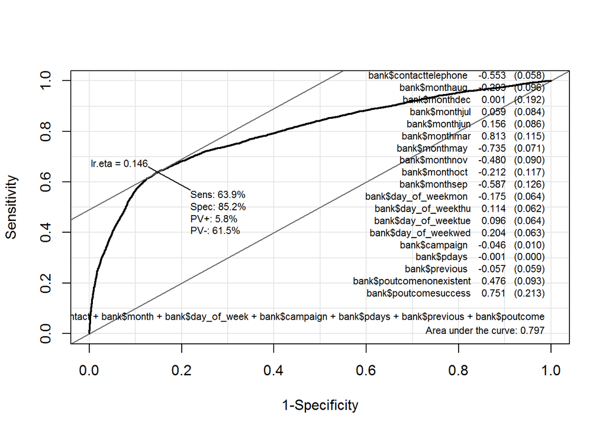

```r
#Output the sensitivity, specificity, and ROC plot
Epi::ROC(form=bank$y_new ~ bank$nr.employed+bank$cons.conf.idx+bank$age+bank$job+bank$marital+bank$education+bank$housing+bank$loan+bank$contact+bank$month+bank$day_of_week+bank$campaign+bank$pdays+bank$previous+bank$poutcome, plot="ROC")
p<-Epi::ROC(form=bank$y_new ~ bank$nr.employed+bank$cons.conf.idx+bank$age+bank$job+bank$marital+bank$education+bank$housing+bank$loan+bank$contact+bank$month+bank$day_of_week+bank$campaign+bank$pdays+bank$previous+bank$poutcome, plot="ROC")
```

```r
m17auc<-round(p$AUC,3)

#Pseudo Rsquared
m17csr2<-DescTools::PseudoR2(logmodel17, which="CoxSnell")
m17csr2
```

```
##  CoxSnell
## 0.1509747
```

```r
m17knr2<-DescTools::PseudoR2(logmodel17, which="Nagelkerke")
m17knr2
```

```
## Nagelkerke
##  0.2836976
```

The AUC of the model is: 0.797

The pseudo R square indicate that between 15.1% and 28.37% of the variability of responses to whether the customer opts for the term deposit or not.

```r
#Summary of the model with co-efficients
stargazer(logmodel17, type="text")
```

```
##
## ========================================================
##                                  Dependent variable:
##                              ---------------------------
##                                         y_new
## --------------------------------------------------------
## nr.employed                           -0.011***
##                                       (0.0003)
##
## cons.conf.idx                         0.018***
##                                        (0.005)
##
## age                                    0.0004
##                                        (0.002)
##
## jobblue-collar                        -0.167**
##                                        (0.079)
##
## jobentrepreneur                        -0.088
##                                        (0.119)
##
## jobhousemaid                           -0.014
##                                        (0.145)
##
## jobmanagement                          -0.042
##                                        (0.081)
##
## jobretired                             0.266**
##                                        (0.107)
##
## jobself-employed                       -0.037
##                                        (0.109)
##
## jobservices                            -0.155*
##                                        (0.084)
##
## jobstudent                             0.282**
##                                        (0.113)
##
## jobtechnician                          -0.018
```

[output cut: 86 more lines]

```
## poutcomenonexistent                   0.476***
##                                        (0.093)
##
## poutcomesuccess                       0.751***
##                                        (0.213)
##
## Constant                              55.039***
##                                        (1.672)
##
## --------------------------------------------------------
## Observations                           30,488
## Log Likelihood                       -9,085.100
## Akaike Inf. Crit.                    18,256.200
## ========================================================
## Note:                        *p<0.1; **p<0.05; ***p<0.01
```

# Rejected list of predictors

1. Age of the customer predictor rejected as Probability >0.05
2. Job of the customer predictor rejected as Probability >0.05 for 70% categories.
3. Marital status of the customer predictor rejected as Probability >0.05
4. Education of the customer predictor rejected as Probability >0.05
5. Housing loan status Predictor rejected as Probability >0.05
6. Personal loan status Predictor rejected as Probability >0.05
7. Number of contacts performed before this campaign and for this client predictor rejected as Probability >0.05

## Model-18 | nr.employed, cons.conf.idx, contact, month, day_of_week, campaign, pdays and poutcome as predictor

```r
logmodel18 <- glm(y_new ~ nr.employed+cons.conf.idx+contact+month+day_of_week+campaign+pdays+poutcome , data = bank, na.action = na.exclude, family = binomial(link=logit))

#Full summary of the model
summary(logmodel18)
```

```
##
## Call:
## glm(formula = y_new ~ nr.employed + cons.conf.idx + contact +
##     month + day_of_week + campaign + pdays + poutcome, family = binomial(link = logit),
##     data = bank, na.action = na.exclude)
##
## Deviance Residuals:
##     Min       1Q   Median       3Q      Max
## -2.1993  -0.4076  -0.3431  -0.2639   2.9290
##
## Coefficients:
##                       Estimate Std. Error z value Pr(>|z|)
## (Intercept)         56.6646569  1.5756463  35.963  < 2e-16 ***
## nr.employed         -0.0110610  0.0003165 -34.947  < 2e-16 ***
## cons.conf.idx        0.0208225  0.0045631   4.563 5.04e-06 ***
## contacttelephone    -0.5564892  0.0581582  -9.569  < 2e-16 ***
## monthaug            -0.2543191  0.0944607  -2.692 0.007096 **
## monthdec             0.0411563  0.1905931   0.216 0.829036
## monthjul             0.0592064  0.0831708   0.712 0.476549
## monthjun             0.1581617  0.0856691   1.846 0.064864 .
## monthmar             0.8446878  0.1144307   7.382 1.56e-13 ***
## monthmay            -0.7746828  0.0704545 -10.996  < 2e-16 ***
## monthnov            -0.4774139  0.0892720  -5.348 8.90e-08 ***
## monthoct            -0.2022403  0.1163954  -1.738 0.082294 .
## monthsep            -0.5926800  0.1252822  -4.731 2.24e-06 ***
## day_of_weekmon      -0.1779605  0.0643843  -2.764 0.005709 **
## day_of_weekthu       0.1159525  0.0620690   1.868 0.061745 .
## day_of_weektue       0.0940121  0.0639257   1.471 0.141387
## day_of_weekwed       0.2043532  0.0632091   3.233 0.001225 **
## campaign            -0.0445718  0.0104414  -4.269 1.97e-05 ***
## pdays               -0.0010770  0.0002038  -5.285 1.26e-07 ***
## poutcomenonexistent  0.5515647  0.0616272   8.950  < 2e-16 ***
## poutcomesuccess      0.7916997  0.2049195   3.863 0.000112 ***
## ---
## Signif. codes:  0 '***' 0.001 '**' 0.01 '*' 0.05 '.' 0.1 ' ' 1
##
## (Dispersion parameter for binomial family taken to be 1)
##
##     Null deviance: 23160  on 30487  degrees of freedom
## Residual deviance: 18218  on 30467  degrees of freedom
## AIC: 18260
##
## Number of Fisher Scoring iterations: 5
```

```r
#Chi-square plus significance
lmtest::lrtest(logmodel17,logmodel18)
```

|  | #Df | LogLik | Df | Chisq | Pr(>Chisq) |
| --- | --- | --- | --- | --- | --- |
| 1 | 43 | -9085.100 | NA | NA | NA |
| 2 | 21 | -9108.943 | -22 | 47.6866 | 0.00119322 |

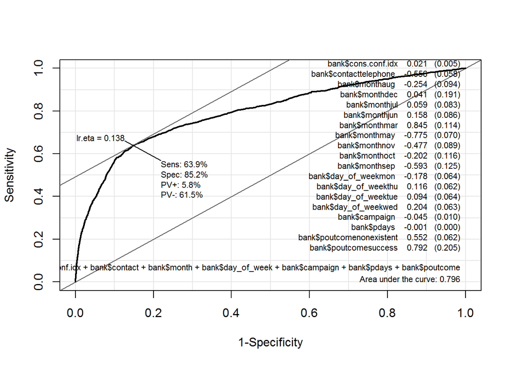

```r
#Output the sensitivity, specificity, and ROC plot
Epi::ROC(form=bank$y_new ~ bank$nr.employed+bank$cons.conf.idx+bank$contact+bank$month+bank$day_of_week+bank$campaign+bank$pdays+bank$poutcome, plot="ROC")
p<-Epi::ROC(form=bank$y_new ~ bank$nr.employed+bank$cons.conf.idx+bank$contact+bank$month+bank$day_of_week+bank$campaign+bank$pdays+bank$poutcome, plot="ROC")
```

```r
m18auc<-round(p$AUC,3)

#Pseudo Rsquared
m18csr2<-DescTools::PseudoR2(logmodel18, which="CoxSnell")
m18csr2
```

```
##  CoxSnell
## 0.1496457
```

```r
m18knr2<-DescTools::PseudoR2(logmodel18, which="Nagelkerke")
m18knr2
```

```
## Nagelkerke
##  0.2812003
```

The AUC of the model is: 0.796

The pseudo R square indicate that between 14.96% and 28.12% of the variability of responses to whether the customer opts for the term deposit or not.

```r
#Summary of the model with co-efficients
stargazer(logmodel18, type="text")
```

```
##
## ===============================================
##                         Dependent variable:
##                     ---------------------------
##                                y_new
## -----------------------------------------------
## nr.employed                  -0.011***
##                              (0.0003)
##
## cons.conf.idx                0.021***
##                               (0.005)
##
## contacttelephone             -0.556***
##                               (0.058)
##
## monthaug                     -0.254***
##                               (0.094)
##
## monthdec                       0.041
##                               (0.191)
##
## monthjul                       0.059
##                               (0.083)
##
## monthjun                      0.158*
##                               (0.086)
##
## monthmar                     0.845***
##                               (0.114)
##
## monthmay                     -0.775***
##                               (0.070)
##
## monthnov                     -0.477***
##                               (0.089)
##
## monthoct                      -0.202*
##                               (0.116)
##
## monthsep                     -0.593***
```

[output cut: 20 more lines]

```
## poutcomenonexistent          0.552***
##                               (0.062)
##
## poutcomesuccess              0.792***
##                               (0.205)
##
## Constant                     56.665***
##                               (1.576)
##
## -----------------------------------------------
## Observations                  30,488
## Log Likelihood              -9,108.943
## Akaike Inf. Crit.           18,259.890
## ===============================================
## Note:               *p<0.1; **p<0.05; ***p<0.01
```

# Confusion Matrix

```r
#Confusion matrix
regclass::confusion_matrix(logmodel18)
```

```
##          Predicted 0 Predicted 1 Total
## Actual 0       26154         475 26629
## Actual 1        2909         950  3859
## Total          29063        1425 30488
```

#Check the assumption of linearity of independent variables and log odds using a Hosmer-Lemeshow test

```r
generalhoslem::logitgof(bank$y_new, fitted(logmodel18))
```

```
##
##  Hosmer and Lemeshow test (binary model)
##
## data:  bank$y_new, fitted(logmodel18)
## X-squared = 29.828, df = 8, p-value = 0.0002267
```

# Check the assumption of Collinearity

```r
#Collinearity
vifmodel<-car::vif(logmodel18)#You can ignore the warning messages, GVIF^(1/(2*Df)) is the value of interest
vifmodel
```

```
##                    GVIF Df GVIF^(1/(2*Df))
## nr.employed    1.902671  1        1.379373
## cons.conf.idx  1.959422  1        1.399793
## contact        1.329973  1        1.153244
## month          3.437617  9        1.071006
## day_of_week    1.041078  4        1.005045
## campaign       1.038325  1        1.018982
## pdays          9.635070  1        3.104041
## poutcome      10.657328  2        1.806808
```

```r
#Tolerance
1/vifmodel
```

```
##                     GVIF        Df GVIF^(1/(2*Df))
## nr.employed   0.52557697 1.0000000       0.7249669
## cons.conf.idx 0.51035470 1.0000000       0.7143911
## contact       0.75189506 1.0000000       0.8671188
## month         0.29089915 0.1111111       0.9337012
## day_of_week   0.96054278 0.2500000       0.9949805
## campaign      0.96308937 1.0000000       0.9813712
## pdays         0.10378752 1.0000000       0.3221607
## poutcome      0.09383215 0.5000000       0.5534621
```

## Findings

We created a model with above attributes. Examination for multicollinearity showed that the tolerance and variance influence factor measures for ‘Number of days that passed by after the client was last contacted from a previous campaign’ (pdays) predictor were not within acceptable levels (tolerance >0.4, VIF <2.5 ) as outlined in Tarling (2008). So, ‘Number of days that passed by after the client was last contacted from a previous campaign’ (pdays) is removed from the final model.

## Model-18 | nr.employed, cons.conf.idx, contact, month, day_of_week, campaign and poutcome as predictor

```r
logmodel18 <- glm(y_new ~ nr.employed+cons.conf.idx+contact+month+day_of_week+campaign+poutcome , data = bank, na.action = na.exclude, family = binomial(link=logit))

#Full summary of the model
summary(logmodel18)
```

```
##
## Call:
## glm(formula = y_new ~ nr.employed + cons.conf.idx + contact +
##     month + day_of_week + campaign + poutcome, family = binomial(link = logit),
##     data = bank, na.action = na.exclude)
##
## Deviance Residuals:
##     Min       1Q   Median       3Q      Max
## -2.2006  -0.4132  -0.3426  -0.2625   2.9299
##
## Coefficients:
##                       Estimate Std. Error z value Pr(>|z|)
## (Intercept)         56.3017476  1.5711385  35.835  < 2e-16 ***
## nr.employed         -0.0111895  0.0003149 -35.532  < 2e-16 ***
## cons.conf.idx        0.0209211  0.0045587   4.589 4.45e-06 ***
## contacttelephone    -0.5508476  0.0580895  -9.483  < 2e-16 ***
## monthaug            -0.2275937  0.0942026  -2.416  0.01569 *
## monthdec             0.0368630  0.1902134   0.194  0.84633
## monthjul             0.0807264  0.0830125   0.972  0.33082
## monthjun             0.1712033  0.0855511   2.001  0.04537 *
## monthmar             0.8547342  0.1142441   7.482 7.34e-14 ***
## monthmay            -0.7690528  0.0703445 -10.933  < 2e-16 ***
## monthnov            -0.4509659  0.0889079  -5.072 3.93e-07 ***
## monthoct            -0.1911395  0.1162008  -1.645  0.09999 .
## monthsep            -0.5925321  0.1250245  -4.739 2.14e-06 ***
## day_of_weekmon      -0.1750870  0.0643212  -2.722  0.00649 **
## day_of_weekthu       0.1165783  0.0620130   1.880  0.06012 .
## day_of_weektue       0.0954901  0.0638569   1.495  0.13482
## day_of_weekwed       0.2052466  0.0631289   3.251  0.00115 **
## campaign            -0.0441723  0.0104306  -4.235 2.29e-05 ***
## poutcomenonexistent  0.4853293  0.0594928   8.158 3.41e-16 ***
## poutcomesuccess      1.7838440  0.0839884  21.239  < 2e-16 ***
## ---
## Signif. codes:  0 '***' 0.001 '**' 0.01 '*' 0.05 '.' 0.1 ' ' 1
##
## (Dispersion parameter for binomial family taken to be 1)
##
##     Null deviance: 23160  on 30487  degrees of freedom
## Residual deviance: 18245  on 30468  degrees of freedom
## AIC: 18285
##
## Number of Fisher Scoring iterations: 5
```

```r
#Chi-square plus significance
lmtest::lrtest(logmodel18)
```

|  | #Df | LogLik | Df | Chisq | Pr(>Chisq) |
| --- | --- | --- | --- | --- | --- |
| 1 | 20 | -9122.616 | NA | NA | NA |
| 2 | 1 | -11580.028 | -19 | 4914.823 | 0 |

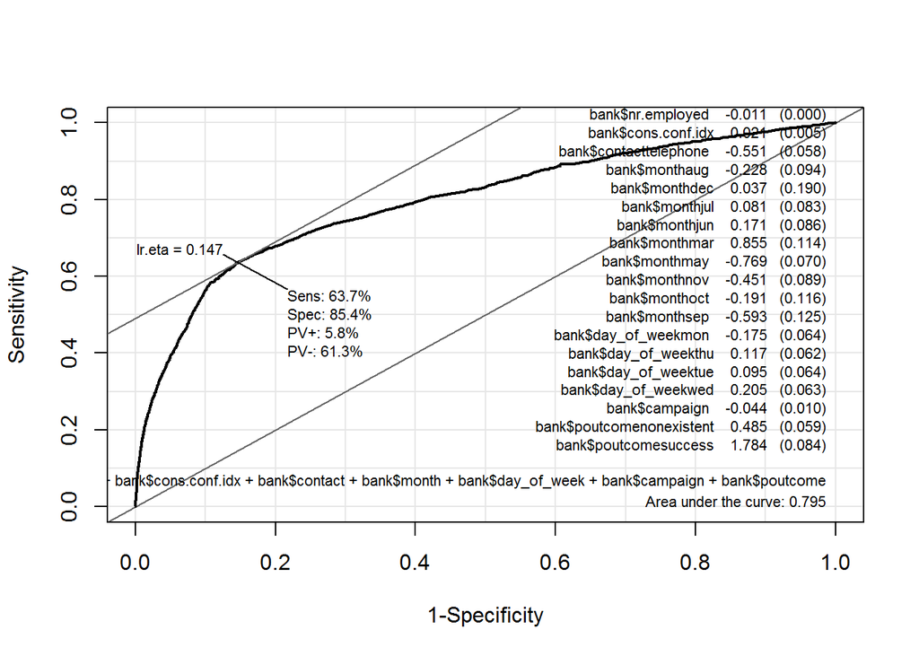

```r
#Output the sensitivity, specificity, and ROC plot
Epi::ROC(form=bank$y_new ~ bank$nr.employed+bank$cons.conf.idx+bank$contact+bank$month+bank$day_of_week+bank$campaign+bank$poutcome, plot="ROC")
p<-Epi::ROC(form=bank$y_new ~ bank$nr.employed+bank$cons.conf.idx+bank$contact+bank$month+bank$day_of_week+bank$campaign+bank$poutcome, plot="ROC")
```

```r
m18auc<-round(p$AUC,3)

#Pseudo Rsquared
m18csr2<-DescTools::PseudoR2(logmodel18, which="CoxSnell")
m18csr2
```

```
##  CoxSnell
## 0.1488826
```

```r
m18knr2<-DescTools::PseudoR2(logmodel18, which="Nagelkerke")
m18knr2
```

```
## Nagelkerke
##  0.2797664
```

The AUC of the model is: 0.795

The pseudo R square indicate that between 14.89% and 27.98% of the variability of responses to whether the customer opts for the term deposit or not.

```r
#Summary of the model with co-efficients
stargazer(logmodel18, type="text")
```

```
##
## ===============================================
##                         Dependent variable:
##                     ---------------------------
##                                y_new
## -----------------------------------------------
## nr.employed                  -0.011***
##                              (0.0003)
##
## cons.conf.idx                0.021***
##                               (0.005)
##
## contacttelephone             -0.551***
##                               (0.058)
##
## monthaug                     -0.228**
##                               (0.094)
##
## monthdec                       0.037
##                               (0.190)
##
## monthjul                       0.081
##                               (0.083)
##
## monthjun                      0.171**
##                               (0.086)
##
## monthmar                     0.855***
##                               (0.114)
##
## monthmay                     -0.769***
##                               (0.070)
##
## monthnov                     -0.451***
##                               (0.089)
##
## monthoct                      -0.191*
##                               (0.116)
##
## monthsep                     -0.593***
```

[output cut: 17 more lines]

```
## poutcomenonexistent          0.485***
##                               (0.059)
##
## poutcomesuccess              1.784***
##                               (0.084)
##
## Constant                     56.302***
##                               (1.571)
##
## -----------------------------------------------
## Observations                  30,488
## Log Likelihood              -9,122.616
## Akaike Inf. Crit.           18,285.230
## ===============================================
## Note:               *p<0.1; **p<0.05; ***p<0.01
```